# DATA100 Introduction to Data Analytics

Lecture 5: Exploratory Data Analysis

Agassi Iu

Wilfrid Laurier University

2026-09-24

## The EDA loop

EDA is not a procedure with a checklist. It’s a cycle you run until the questions stop being interesting:

1. Generate questions about your data
2. Search for answers by visualizing, transforming, and modelling
3. Refine your questions, or generate new ones from what you found

Most of what you produce during EDA gets thrown away, and that’s okay!

## Why it’s not optional

**Important note**

Dead ends are expected and not failure.

Even when the research question arrives fully formed, you still have to know whether the data can answer it.

**Data cleaning**

A *special case* of EDA: you’re asking whether the data meets your expectations, and using the same tools like visualization, transformation, modelling to find out.

## Two Guiding Questions

1. What **variation** occurs *within* my variables?
2. What **covariation** occurs *between* my variables?

**Variation**

How much a single variable’s values differ from one observation to the next. Even measuring the same quantity repeatedly gives slightly different results, and real differences between subjects or across time add even more spread.

**Covariation**

The tendency for two or more variables to move together. If two variables covary, knowing the value of one improves your guess about the other.

## A simple example

Weigh 10 apples from the same tree:

142g, 138g, 151g, 145g, 149g, 133g, 156g, 144g, 140g, 147g

That spread, some apples heavier, some lighter, is **variation**: natural differences within one variable, even from apples off the same tree.

Now also measure each apple’s diameter:

| Diameter (cm) | Weight (g) |
| --- | --- |
| 6.5 | 133 |
| 7.0 | 140 |
| 7.8 | 151 |
| 8.1 | 156 |

Bigger diameter tends to mean more weight. The two variables move together, that’s **covariation**. Knowing one lets you make a real guess about the other.

# Variation

## Variation

**Variation**

The tendency of a variable’s values to change from one measurement to thenext.

- Even a perfectly constant quantity will read slightly differently each time you measure it. That’s measurement noise.
- Real variables also differ between subjects and over time on top of that noise, and the combination gives every variable its own characteristic shape.
- Some cluster tightly, some spread wide, some have several common values.
- You can’t see that shape in a long column of numbers. **Plotting the distribution is how you see it.**

## The Diamond Data

| Variable | Meaning |
| --- | --- |
| `price` | price in US dollars |
| `carat` | weight of the diamond |
| `cut` | quality of the cut: Fair, Good, Very Good, Premium, Ideal |
| `color` | diamond color, from J (worst) to D (best) |
| `clarity` | how clear the diamond is: I1 (worst) to IF (best) |
| `x`, `y`, `z` | length, width, depth in mm |
| `depth` | total depth percentage |
| `table` | width of the top of the diamond relative to widest point |

## A first look

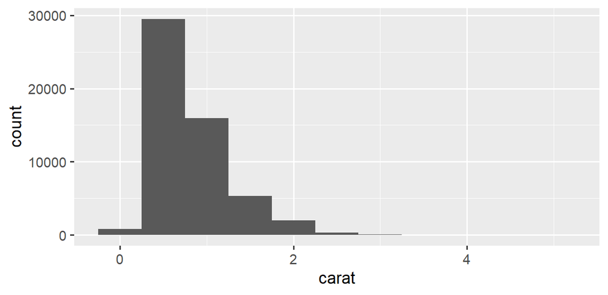

```r
ggplot(diamonds, aes(x = carat)) +
  geom_histogram(binwidth = 0.5)
```

## Changing the Binwidth

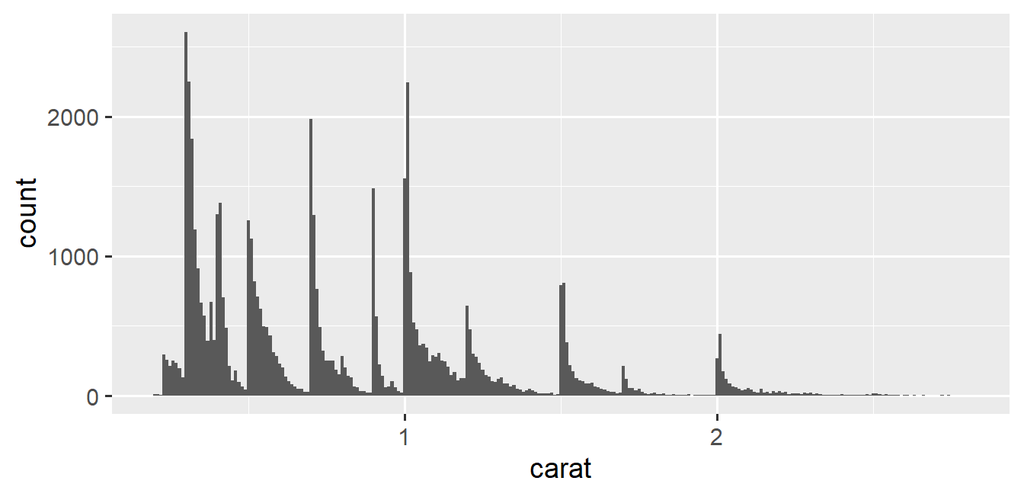

```r
ggplot(smaller, aes(x = carat)) +
  geom_histogram(binwidth = 0.01)
```

Same data. A much narrower bin reveals structure the first plot hid entirely.

## Typical values: what to ask

**Checkpoint**

1. Which values are most common? Why?
2. Which are rare? Does that match what you expected?
3. What are the gaps?
4. Are there unexpected patterns? What could explain them?

For the carat histogram: why the spikes at whole carats and common fractions? And why more diamonds just *above* each spike than just below?

## Clusters mean subgroups

When a distribution separates into clumps, you can ask yourself:

- How are observations *within* a cluster alike?
- How do clusters differ from each other?
- What explains the split?
- Could the clusters be an artifact rather than real structure?

**Recall from last week**

The three clusters from Financial Wellness data: stressed, coping, and comfortable.

## Unusual values hide in plain sight

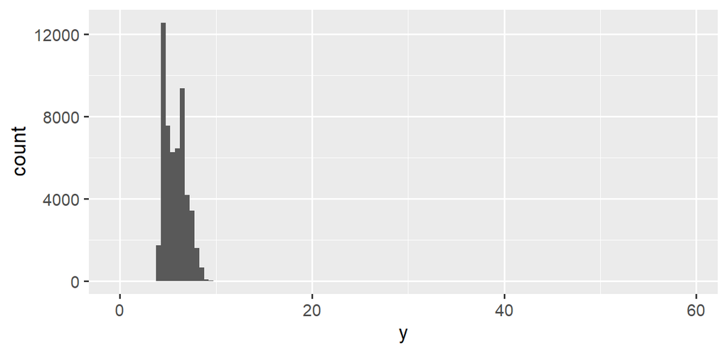

```r
ggplot(diamonds, aes(x = y)) +
  geom_histogram(binwidth = 0.5)
```

The only hint of anything odd is how wide the x-axis is.

## Zoom in on the y-axis

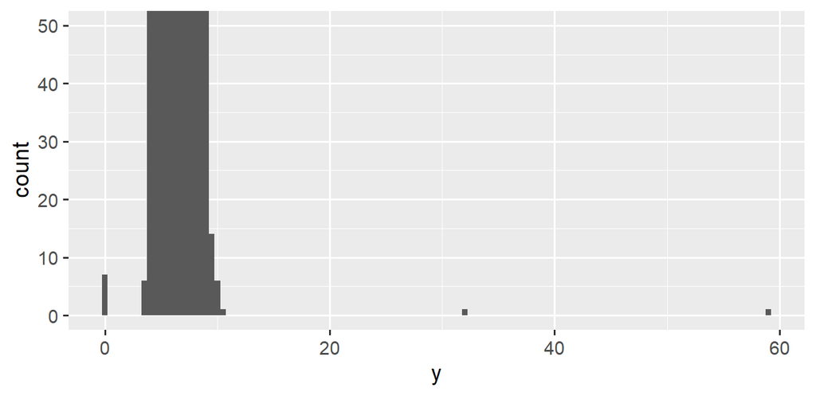

```r
ggplot(diamonds, aes(x = y)) +
  geom_histogram(binwidth = 0.5) +
  coord_cartesian(ylim = c(0, 50))
```

## Zooming In

Now three unusual regions show up: near 0, around 30, and around 60.

**`coord_cartesian()`**

The bars are still computed from *all* the data, so you can safely zoom the y-axis to see rare bins without changing what got counted.

`ylim()`/`xlim()` instead **discard** any data outside the limits before the stat runs, which can silently change your bar heights.

When you just want a closer look, reach for `coord_cartesian()`.

## Outliers

A value that sits far away from the rest of a variable’s values, unusual enough that it stands out from the general pattern. Outliers can come from a few different places:

**A real, unusual observation**

The value is correct. It just represents something genuinely rare, an extremely large diamond, an exceptionally tall person.

**A measurement or data entry error**

The value is wrong. A typo, a broken sensor, a missing value coded as 0 instead of NA. This is common and worth checking first.

**Why they matter**

An outlier can quietly distort summaries like the mean or a fitted trend line, so it’s worth investigating rather than ignoring. But it should never be dropped automatically just because it’s inconvenient, understanding *why* it’s unusual comes first.

You can’t always spot an outlier from a column of numbers. Plotting the distribution, and sometimes zooming in, is usually what reveals it.

## Pull the outliers out

```r
unusual <- diamonds |>
  filter(y < 3 | y > 20) |>
  select(price, x, y, z) |>
  arrange(y)

unusual
```

```
# A tibble: 9 × 4
  price     x     y     z
  <int> <dbl> <dbl> <dbl>
1  5139  0      0    0
2  6381  0      0    0
3 12800  0      0    0
4 15686  0      0    0
5 18034  0      0    0
6  2130  0      0    0
7  2130  0      0    0
8  2075  5.15  31.8  5.12
9 12210  8.09  58.9  8.06
```

## What we found

`y` is a dimension in millimeters. A diamond cannot be 0 mm wide, so those are **missing data encoded as zero**.

- You wouldn’t have been able to find these simply by searching for `NA` as missing data.

The 32 mm and 59 mm entries are implausible too!

**Important**

This is the core payoff of EDA: visualizing the data surfaced a data-quality problem that a search for `NA` never would have. Always sanity-check units and physically-plausible ranges, not just missingness flags.

**Caution**

Run your analysis with and without the outliers. If it barely moves and you can’t explain them, dropping them is defensible. If it moves a lot, find the cause and **disclose the removal** in your write-up — don’t drop values without justification just because they’re inconvenient.

## Two ways to handle them

```r
# Option 1: drop the whole row — usually too blunt
diamonds2 <- diamonds |> filter(between(y, 3, 20))

# Option 2: replace the bad value with NA — usually better
diamonds2 <- diamonds |>
  mutate(y = if_else(y < 3 | y > 20, NA, y))
```

**Note**

`filter()` basically isolates the rows where the `y` values are between 3 and 20, while keeping the rest of the variables (as long as their corresponding `y` is between 3 and 20). It discards the rest.

`mutate()` changes (like mutation) the column of `y` such that if `y` is less than 3 **OR** `y` is greater than 20, then the corresponding `y` value becomes `NA`.

## Missing values in plots

ggplot2 won’t guess where to put an `NA`, so it drops them and warns you. Silence the warning with `na.rm = TRUE` (only once you’ve understood why they’re missing).

```r
diamonds2 <- diamonds |> mutate(y = if_else(y < 3 | y > 20, NA, y))

ggplot(diamonds2, aes(x = x, y = y)) +
  geom_point()
```

```
Warning: Removed 9 rows containing missing values or values outside the scale range
(`geom_point()`).
```

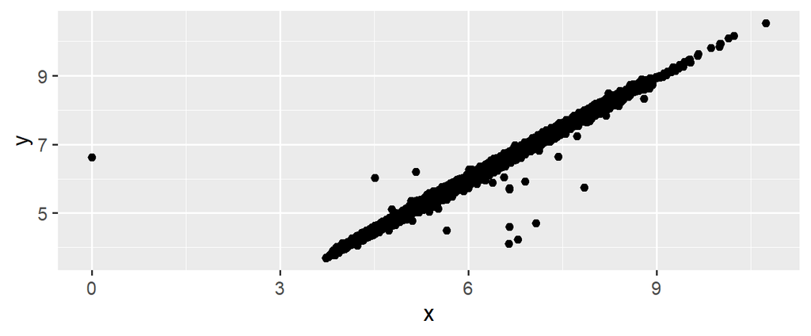

## Your turn

**Try it yourself**

1. Explore the distributions of `x`, `y`, and `z` in `diamonds`. Which is length, which width, which depth?
2. Explore `price`. Try a wide range of binwidths. Anything surprising?
3. How many diamonds are 0.99 carat vs. exactly 1 carat? Why the gap?

# Covariation

## Covariation

If variation describes behavior *within* a variable, **covariation** describes behavior *between* variables: the tendency for two or more variables to move together.

The strategy depends on the variable types:

- categorical × numerical
- categorical × categorical
- numerical × numerical

## Categorical × numerical:

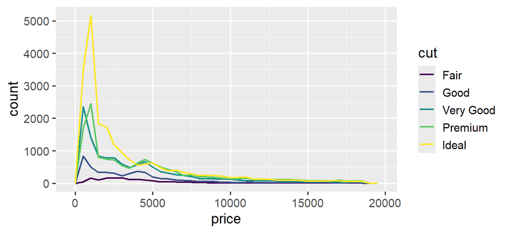

```r
ggplot(diamonds, aes(x = price)) +
  geom_freqpoly(aes(color = cut), binwidth = 500, linewidth = 0.75)
```

**The Count Problem**

Group sizes differ so much that shape differences are invisible. Do you think each `cut` share the same pattern?

## Switch the y-axis to density

**Density** is the count standardized so the area under each curve is 1. Since it isn’t a column in the data, `after_stat()` fetches it from the stat. The following plot is a *frequency polygon*.

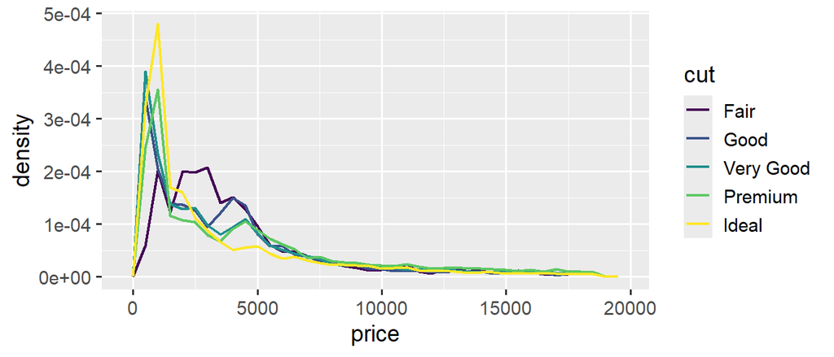

```r
ggplot(diamonds, aes(x = price, y = after_stat(density))) +
  geom_freqpoly(aes(color = cut), binwidth = 500, linewidth = 0.75)
```

## Frequency polygons vs Boxplots

Fair diamonds (the *lowest* quality cut) appear to have the highest average price.

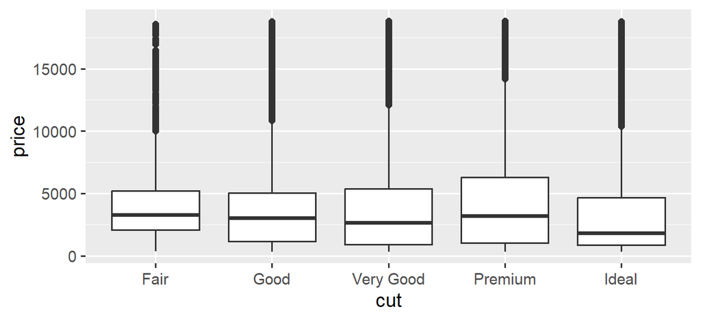

```r
ggplot(diamonds, aes(x = cut, y = price)) +
  geom_boxplot()
```

## Reordering

`cut` is an ordered factor, so its order is meaningful. Most categorical variables aren’t.

**Ordered Cuts**

It goes from Fair -> Good -> Very Good -> Premium -> Ideal.

**What do you do if the categories are: Apples, Oranges, Bananas?**

This `fct_reorder(variable, by, fun)` function sorts factor levels by a summary statistic (e.g. mean/median) of another variable, which almost always makes a categorical-vs-numeric plot easier to read at a glance.

## Example

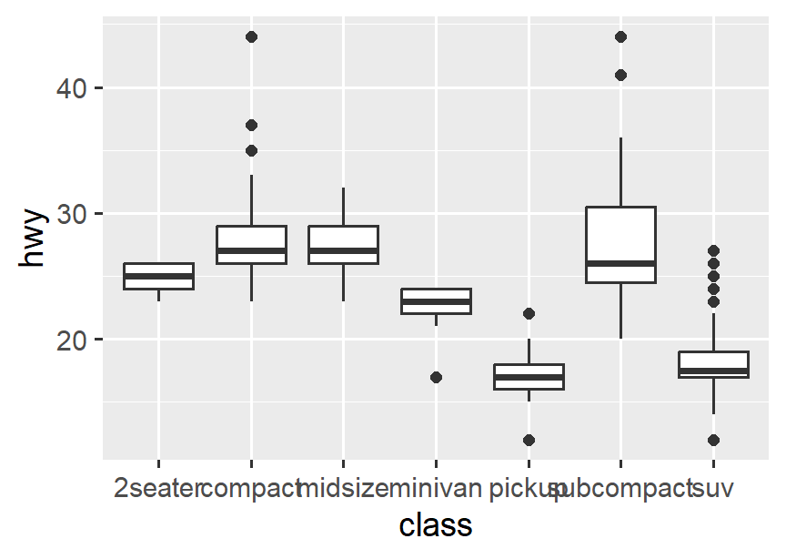

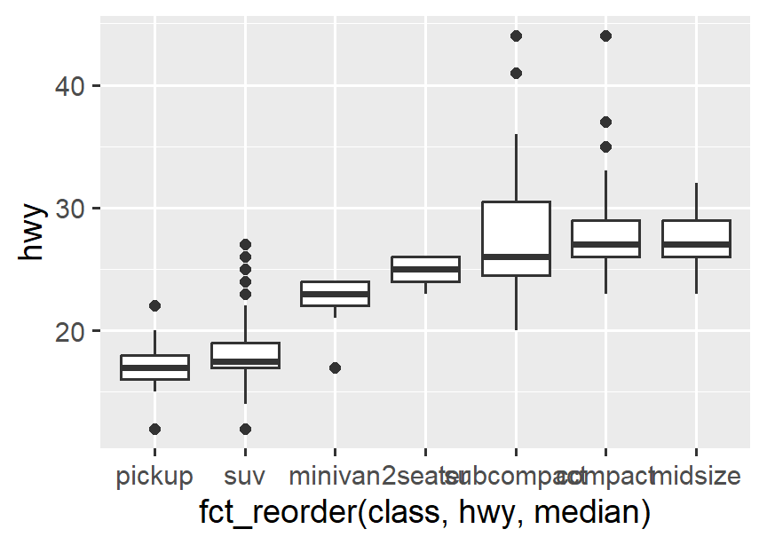

```r
ggplot(mpg, aes(x = class, y = hwy)) + geom_boxplot()
ggplot(mpg, aes(x = fct_reorder(class, hwy, median), y = hwy)) + geom_boxplot()
```

## Flip when labels are long

Swap the x and y mappings with no extra function needed:

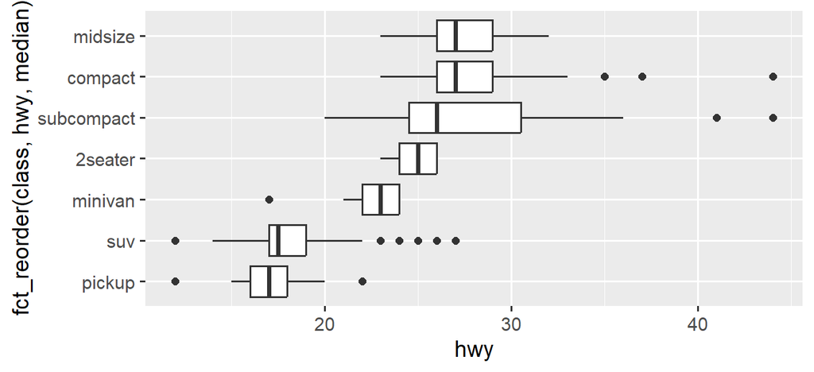

```r
ggplot(mpg, aes(x = hwy, y = fct_reorder(class, hwy, median))) +
  geom_boxplot()
```

## Your turn

**Try it yourself**

Recall that there are variables such as `price`, `carat`, `cut`, `color`, `clarity`, `x`, `y`, `z`, `depth`, and `table`.

Earlier we saw that `Fair` cut diamonds look more expensive on average than `Ideal` cut diamonds, which may be the opposite of what you’d expect. `carat` (the diamond’s weight) turns out to be the strongest predictor of `price` in the whole dataset.

1. Plot `price` against `carat`. Does the relationship look strong?
2. Now plot `carat` against `cut`. Is `carat` spread evenly across cut qualities, or do `Fair` diamonds skew toward one end?
3. Why does `Fair` diamonds skewing that way in `carat` make them look pricier overall, even though a worse cut should, on its own, lower the price?

## Categorical × categorical: counts

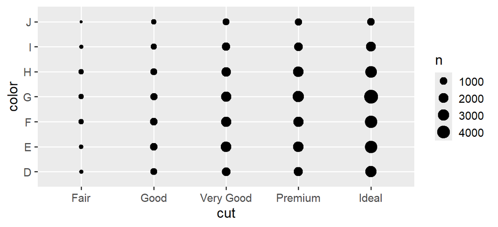

```r
ggplot(diamonds, aes(x = cut, y = color)) +
  geom_count()
```

Circle area shows how many observations fall at each combination.

## `geom_tile()`

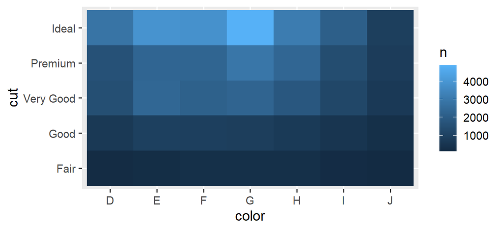

```r
diamonds |>
  count(color, cut) |>
  ggplot(aes(x = color, y = cut)) +
  geom_tile(aes(fill = n))
```

## Numerical × numerical

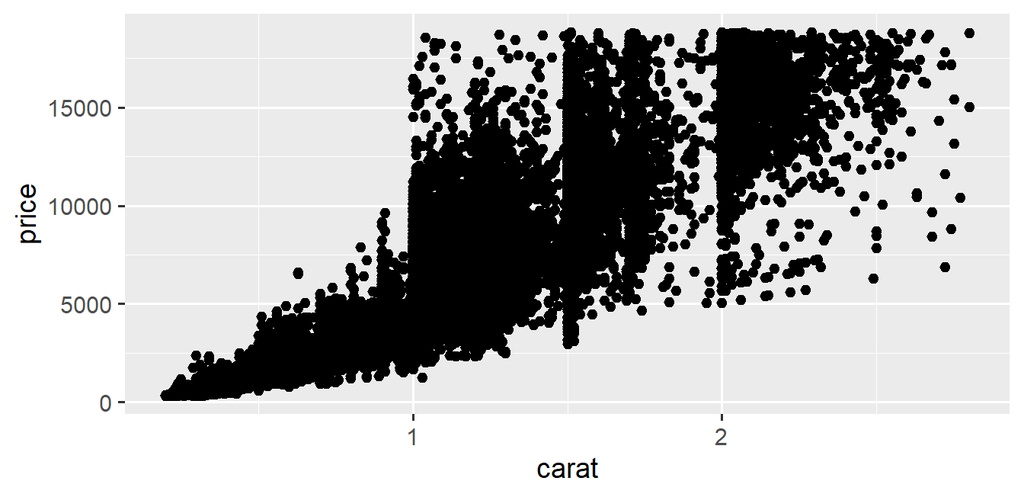

```r
ggplot(smaller, aes(x = carat, y = price)) +
  geom_point()
```

Would you argue that there is a lot of overplotting in this figure?

## Transparency helps

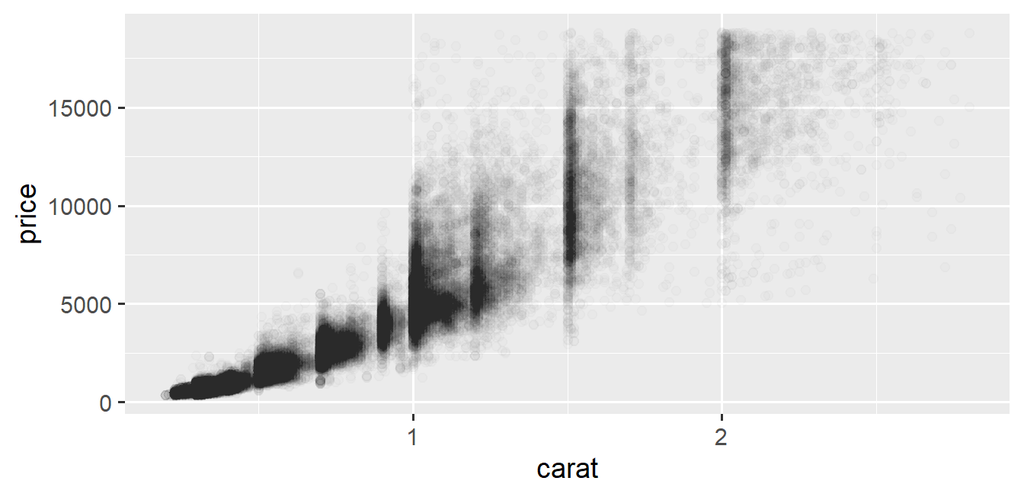

```r
ggplot(smaller, aes(x = carat, y = price)) +
  geom_point(alpha = 1 / 100)
```

Clusters at 1, 1.5, and 2 carats become visible.

## Bin + Boxplots ?

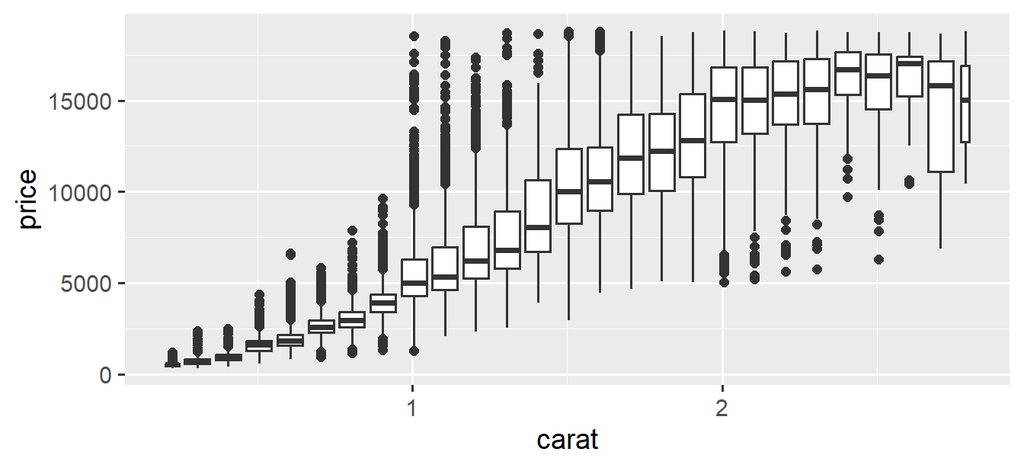

```r
ggplot(smaller, aes(x = carat, y = price)) +
  geom_boxplot(aes(group = cut_width(carat, 0.1)))
```

`cut_width(x, width)` slices `x` into equal-width bins. Can you comment on this plot?

# Patterns and models

## Interrogating a pattern

A systematic relationship shows up as a pattern. When you spot one, try and ask yourself:

- Could this be coincidence?
- How would you describe the relationship?
- How strong is it?
- What other variables might be involved?
- Does it hold within subgroups?

## Variation vs. covariation

**Variation** is uncertainty within a single variable. If `price` varies a lot on its own, knowing nothing else, you can’t say much about what a given diamond costs. **Covariation** between variables cuts that uncertainty down.

**Tip**

If `carat` and `price` covary, then knowing a diamond’s `carat` narrows down your guess for its `price` a lot more than guessing blind. The stronger the covariation, the more one variable tells you about the other.

## Modelling

This is the entire logic behind prediction and modelling: a **useful** predictor is just a variable that **covaries** with the outcome you care about. A variable that doesn’t covary with the outcome is useless as a predictor, no matter how interesting it looks on its own.

- E.g. `income` with `financial wellness`

**Correlation does not imply causation?**

Covariation is not the same as causation. Two variables can covary because one causes the other, because both are driven by a third variable, or by pure coincidence.

- E.g. The divorce rate in Maine correlates with per capita margarine consumption

## Summary

- EDA is a **loop**:
  - ask questions
  - → visualize/transform/model
  - → formualte better questions
- **Variation** within a variable: typical values, clusters, unusual values
- Outliers are sometimes errors, sometimes discoveries. Investigate before deciding; disclose what you removed.
- **Covariation** between variables: pick the technique by variable type

Next: turning exploratory graphics into ones other people can read.